# NYPD - Shooting project

# NYPD Shooting analysis and prediction

This project is made for the course DTSA-5301 Data Science in the field.

## Libraries to use

First, let’s import the libraries I will use for this project.

```r
library(tidyverse)
```

```r
library(stringr)
library(lubridate)
library(ggplot2)
```

## Loading data

In the first step, let’s load the data from the data source.

```r
url = 'https://data.cityofnewyork.us/api/views/833y-fsy8/rows.csv?accessType=DOWNLOAD'

nypd_dataframe = read.csv(url)
head(nypd_dataframe)
```

|  | INCIDENT_KEY | OCCUR_DATE | OCCUR_TIME | BORO | LOC_OF_OCCUR_DESC | PRECINCT | JURISDICTION_CODE | LOC_CLASSFCTN_DESC | LOCATION_DESC | STATISTICAL_MURDER_FLAG | PERP_AGE_GROUP | PERP_SEX | PERP_RACE | VIC_AGE_GROUP | VIC_SEX | VIC_RACE | X_COORD_CD | Y_COORD_CD | Latitude | Longitude | Lon_Lat |
| --- | --- | --- | --- | --- | --- | --- | --- | --- | --- | --- | --- | --- | --- | --- | --- | --- | --- | --- | --- | --- | --- |
| 1 | 228798151 | 05/27/2021 | 21:30:00 | QUEENS |  | 105 | 0 |  |  | false |  |  |  | 18-24 | M | BLACK | 1058925 | 180924.0 | 40.66296 | -73.73084 | POINT (-73.73083868899994 40.662964620000025) |
| 2 | 137471050 | 06/27/2014 | 17:40:00 | BRONX |  | 40 | 0 |  |  | false |  |  |  | 18-24 | M | BLACK | 1005028 | 234516.0 | 40.81035 | -73.92494 | POINT (-73.92494232599995 40.81035186300006) |
| 3 | 147998800 | 11/21/2015 | 03:56:00 | QUEENS |  | 108 | 0 |  |  | true |  |  |  | 25-44 | M | WHITE | 1007668 | 209836.5 | 40.74261 | -73.91549 | POINT (-73.91549174199997 40.74260663300004) |
| 4 | 146837977 | 10/09/2015 | 18:30:00 | BRONX |  | 44 | 0 |  |  | false |  |  |  | <18 | M | WHITE HISPANIC | 1006537 | 244511.1 | 40.83778 | -73.91946 | POINT (-73.91945661499994 40.83778200300003) |
| 5 | 58921844 | 02/19/2009 | 22:58:00 | BRONX |  | 47 | 0 |  |  | true | 25-44 | M | BLACK | 45-64 | M | BLACK | 1024922 | 262189.4 | 40.88624 | -73.85291 | POINT (-73.85290950899997 40.88623791800006) |
| 6 | 219559682 | 10/21/2020 | 21:36:00 | BROOKLYN |  | 81 | 0 |  |  | true |  |  |  | 25-44 | M | BLACK | 1004234 | 186461.7 | 40.67846 | -73.92795 | POINT (-73.92795224099996 40.678456718000064) |

First lets look if there are null variables.

```r
apply(is.na(nypd_dataframe), 2, sum)
```

```
##            INCIDENT_KEY              OCCUR_DATE              OCCUR_TIME
##                       0                       0                       0
##                    BORO       LOC_OF_OCCUR_DESC                PRECINCT
##                       0                       0                       0
##       JURISDICTION_CODE      LOC_CLASSFCTN_DESC           LOCATION_DESC
##                       2                       0                       0
## STATISTICAL_MURDER_FLAG          PERP_AGE_GROUP                PERP_SEX
##                       0                       0                       0
##               PERP_RACE           VIC_AGE_GROUP                 VIC_SEX
##                       0                       0                       0
##                VIC_RACE              X_COORD_CD              Y_COORD_CD
##                       0                       0                       0
##                Latitude               Longitude                 Lon_Lat
##                      10                      10                       0
```

```r
nypd_dataframe <- nypd_dataframe %>%
  mutate(Longitude = if_else(is.na(Longitude), mean(Longitude), Longitude),
         Latitude = if_else(is.na(Latitude), mean(Latitude), Latitude),
         JURISDICTION_CODE = if_else(is.na(JURISDICTION_CODE), mean(JURISDICTION_CODE), JURISDICTION_CODE))
```

## Visualizing the data

For this project I aim to make a predictor of how much I am in danger giving my geo position, race, sex, and age. So… Let’s explore the data.

### Geo located data

First, let’s see which district of NY has more shootings.

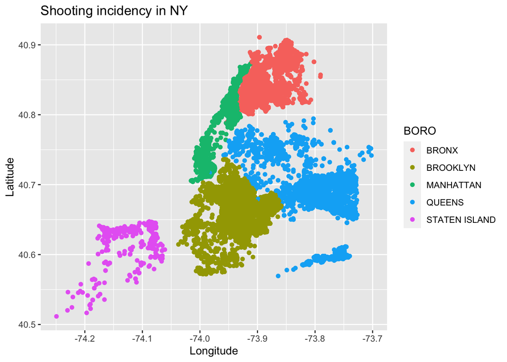

```r
ggplot(nypd_dataframe, aes(x=Longitude, y=Latitude, color=BORO)) +
  geom_point() +
  ggtitle("Shooting incidency in NY")
```

### By ethnicity

What about my race in certain zones?

#### Victim data

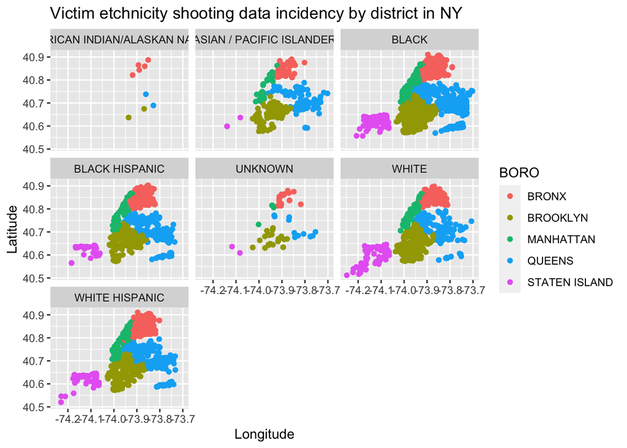

```r
ggplot(nypd_dataframe, aes(x=Longitude, y=Latitude, color=BORO)) +
  geom_point() +
  facet_wrap(~VIC_RACE) +
  ggtitle("Victim etchnicity shooting data incidency by district in NY")
```

```r
count_victims_by_race = nypd_dataframe %>%
  group_by(VIC_RACE) %>%
  summarize(count_victims = n()) %>%
  arrange(count_victims)
count_victims_by_race
```

| VIC_RACE | count_victims |
| --- | --- |
| AMERICAN INDIAN/ALASKAN NATIVE | 10 |
| UNKNOWN | 66 |
| ASIAN / PACIFIC ISLANDER | 404 |
| WHITE | 698 |
| BLACK HISPANIC | 2646 |
| WHITE HISPANIC | 4049 |
| BLACK | 19439 |

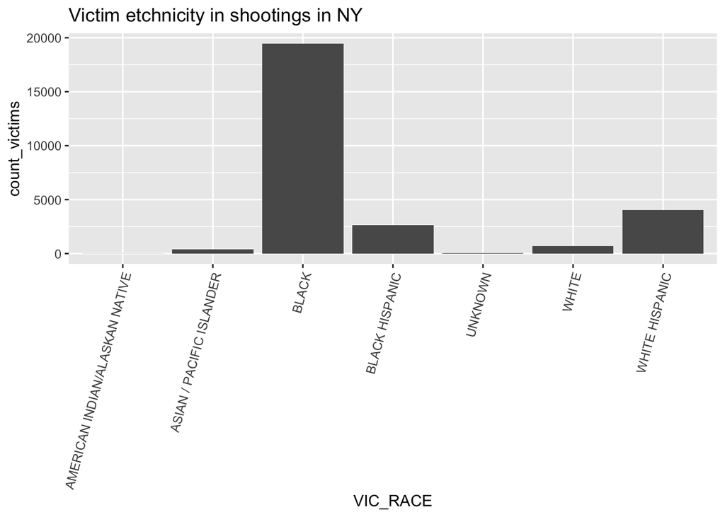

```r
ggplot(count_victims_by_race, aes(x = VIC_RACE, y = count_victims)) +
  geom_bar(stat='identity') +
  theme(axis.text.x = element_text(angle = 75, vjust = 1, hjust=1)) +
  ggtitle("Victim etchnicity in shootings in NY")
```

This previous plot shows which races recieved more shootings in NY. To make a ratio based prediction it is possible to support this barplot with the total number of people in NY by each race. But this is isolated to this project.

##### Age of victims and sex

The next scatter plot shows that Male people around 18 to 44 years are more in danger to get shooted in NY.

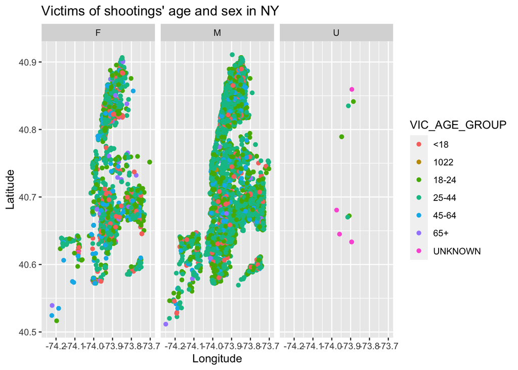

```r
ggplot(nypd_dataframe, aes(x=Longitude, y=Latitude, color=VIC_AGE_GROUP)) +
  geom_point() +
  facet_wrap(~VIC_SEX) +
  ggtitle("Victims of shootings' age and sex in NY")
```

##### Victims’ Sex and Race

Again looking at the victims ethnicity an sex, in the next plot you can see there are four ethnicities which are more victims of shootings (Hispanic Black, Hispanic White, Black, and White).

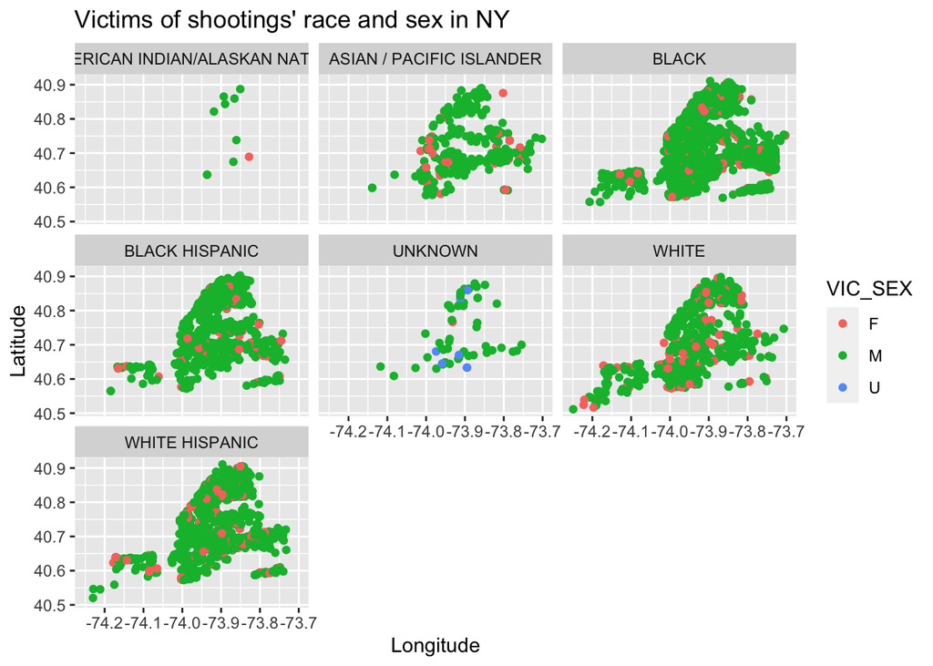

```r
ggplot(nypd_dataframe, aes(x=Longitude, y=Latitude, color=VIC_SEX)) +
  geom_point() +
  facet_wrap(~VIC_RACE) +
  ggtitle("Victims of shootings' race and sex in NY")
```

##### Victims Age and Race

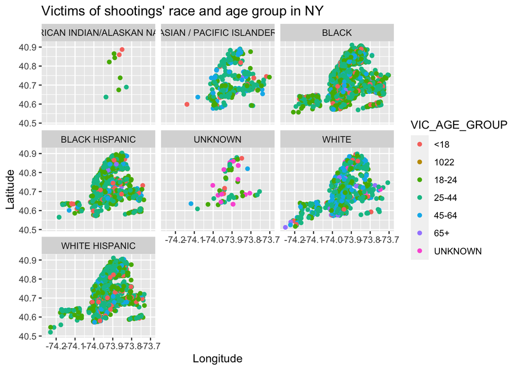

```r
ggplot(nypd_dataframe, aes(x=Longitude, y=Latitude, color=VIC_AGE_GROUP)) +
  geom_point() +
  facet_wrap(~VIC_RACE) +
  ggtitle("Victims of shootings' race and age group in NY")
```

#### Shooter’s data vs Victim’s race

The next plot could be interpreted by “which race is proned to get shoot by the races near by”. This is unfair, but there are several assumptions you can assume looking it, but for ethic reasons we will not make any conclusion about it.

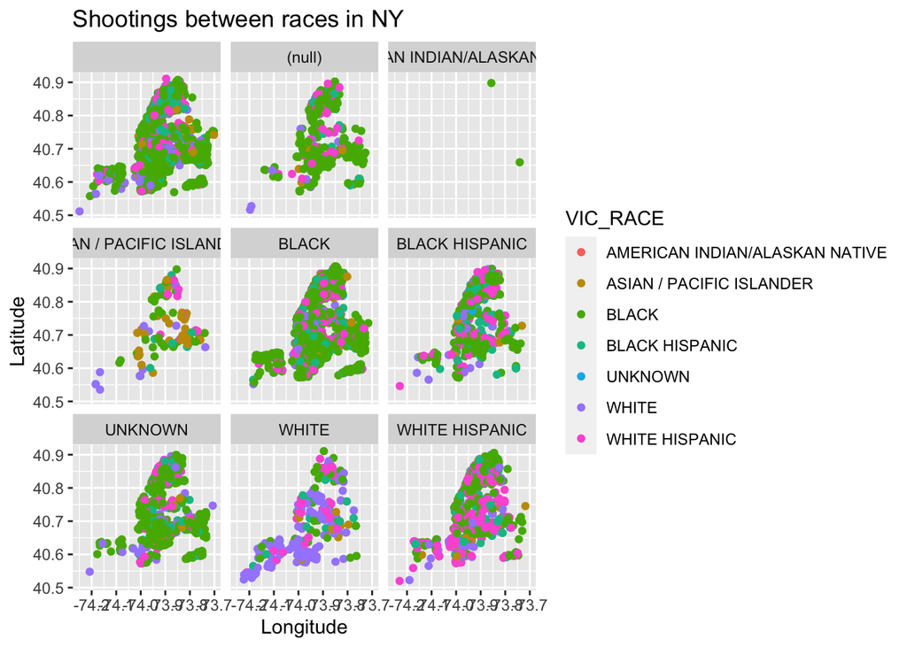

```r
ggplot(nypd_dataframe, aes(x=Longitude, y=Latitude, color=VIC_RACE)) +
  geom_point() +
  facet_wrap(~PERP_RACE) +
  ggtitle("Shootings between races in NY")
```

##### Shooters by BORO

The next plot shows which shooters are most common in each zone of NY.

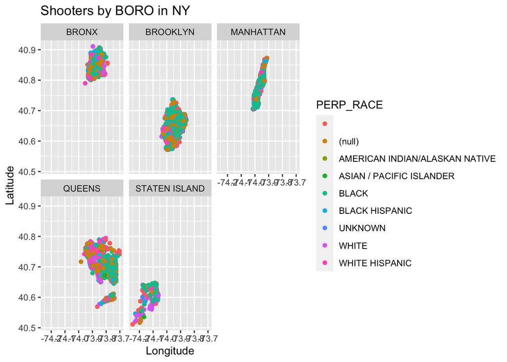

```r
ggplot(nypd_dataframe, aes(x=Longitude, y=Latitude, color=PERP_RACE)) +
  geom_point() +
  facet_wrap(~BORO) +
  ggtitle("Shooters by BORO in NY")
```

## The danger button predictor

We use a logistic regression for the predictor, and for educational purposes our target is if we are near or we are part of a shooting, we will survive to it. Specifically, we are talking to the column STATISTICAL_MURDER_FLAG.

```r
nypd_dataframe <- nypd_dataframe %>%
  mutate(VIC_SEX <- as.factor(VIC_SEX),
         VIC_RACE <- as.factor(VIC_RACE),
         VIC_AGE_GROUP <- as.factor(VIC_AGE_GROUP),
         BORO <- as.factor(BORO)
         )
head(nypd_dataframe)
```

|  | INCIDENT_KEY | OCCUR_DATE | OCCUR_TIME | BORO | LOC_OF_OCCUR_DESC | PRECINCT | JURISDICTION_CODE | LOC_CLASSFCTN_DESC | LOCATION_DESC | STATISTICAL_MURDER_FLAG | PERP_AGE_GROUP | PERP_SEX | PERP_RACE | VIC_AGE_GROUP | VIC_SEX | VIC_RACE | X_COORD_CD | Y_COORD_CD | Latitude | Longitude | Lon_Lat | VIC_SEX <- as.factor(VIC_SEX) | VIC_RACE <- as.factor(VIC_RACE) | VIC_AGE_GROUP <- as.factor(VIC_AGE_GROUP) | BORO <- as.factor(BORO) |
| --- | --- | --- | --- | --- | --- | --- | --- | --- | --- | --- | --- | --- | --- | --- | --- | --- | --- | --- | --- | --- | --- | --- | --- | --- | --- |
| 1 | 228798151 | 05/27/2021 | 21:30:00 | QUEENS |  | 105 | 0 |  |  | false |  |  |  | 18-24 | M | BLACK | 1058925 | 180924.0 | 40.66296 | -73.73084 | POINT (-73.73083868899994 40.662964620000025) | M | BLACK | 18-24 | QUEENS |
| 2 | 137471050 | 06/27/2014 | 17:40:00 | BRONX |  | 40 | 0 |  |  | false |  |  |  | 18-24 | M | BLACK | 1005028 | 234516.0 | 40.81035 | -73.92494 | POINT (-73.92494232599995 40.81035186300006) | M | BLACK | 18-24 | BRONX |
| 3 | 147998800 | 11/21/2015 | 03:56:00 | QUEENS |  | 108 | 0 |  |  | true |  |  |  | 25-44 | M | WHITE | 1007668 | 209836.5 | 40.74261 | -73.91549 | POINT (-73.91549174199997 40.74260663300004) | M | WHITE | 25-44 | QUEENS |
| 4 | 146837977 | 10/09/2015 | 18:30:00 | BRONX |  | 44 | 0 |  |  | false |  |  |  | <18 | M | WHITE HISPANIC | 1006537 | 244511.1 | 40.83778 | -73.91946 | POINT (-73.91945661499994 40.83778200300003) | M | WHITE HISPANIC | <18 | BRONX |
| 5 | 58921844 | 02/19/2009 | 22:58:00 | BRONX |  | 47 | 0 |  |  | true | 25-44 | M | BLACK | 45-64 | M | BLACK | 1024922 | 262189.4 | 40.88624 | -73.85291 | POINT (-73.85290950899997 40.88623791800006) | M | BLACK | 45-64 | BRONX |
| 6 | 219559682 | 10/21/2020 | 21:36:00 | BROOKLYN |  | 81 | 0 |  |  | true |  |  |  | 25-44 | M | BLACK | 1004234 | 186461.7 | 40.67846 | -73.92795 | POINT (-73.92795224099996 40.678456718000064) | M | BLACK | 25-44 | BROOKLYN |

Next, let’s cast the target to 1 or 0.

```r
labeler_murder <- function(val){
  if(val == 'true'){
    return(TRUE)
  }
  return(FALSE)
}
```

```r
nypd_dataframe <- nypd_dataframe %>%
  mutate(STATISTICAL_MURDER_FLAG = sapply(STATISTICAL_MURDER_FLAG, labeler_murder))
head(nypd_dataframe)
```

|  | INCIDENT_KEY | OCCUR_DATE | OCCUR_TIME | BORO | LOC_OF_OCCUR_DESC | PRECINCT | JURISDICTION_CODE | LOC_CLASSFCTN_DESC | LOCATION_DESC | STATISTICAL_MURDER_FLAG | PERP_AGE_GROUP | PERP_SEX | PERP_RACE | VIC_AGE_GROUP | VIC_SEX | VIC_RACE | X_COORD_CD | Y_COORD_CD | Latitude | Longitude | Lon_Lat | VIC_SEX <- as.factor(VIC_SEX) | VIC_RACE <- as.factor(VIC_RACE) | VIC_AGE_GROUP <- as.factor(VIC_AGE_GROUP) | BORO <- as.factor(BORO) |
| --- | --- | --- | --- | --- | --- | --- | --- | --- | --- | --- | --- | --- | --- | --- | --- | --- | --- | --- | --- | --- | --- | --- | --- | --- | --- |
| 1 | 228798151 | 05/27/2021 | 21:30:00 | QUEENS |  | 105 | 0 |  |  | FALSE |  |  |  | 18-24 | M | BLACK | 1058925 | 180924.0 | 40.66296 | -73.73084 | POINT (-73.73083868899994 40.662964620000025) | M | BLACK | 18-24 | QUEENS |
| 2 | 137471050 | 06/27/2014 | 17:40:00 | BRONX |  | 40 | 0 |  |  | FALSE |  |  |  | 18-24 | M | BLACK | 1005028 | 234516.0 | 40.81035 | -73.92494 | POINT (-73.92494232599995 40.81035186300006) | M | BLACK | 18-24 | BRONX |
| 3 | 147998800 | 11/21/2015 | 03:56:00 | QUEENS |  | 108 | 0 |  |  | TRUE |  |  |  | 25-44 | M | WHITE | 1007668 | 209836.5 | 40.74261 | -73.91549 | POINT (-73.91549174199997 40.74260663300004) | M | WHITE | 25-44 | QUEENS |
| 4 | 146837977 | 10/09/2015 | 18:30:00 | BRONX |  | 44 | 0 |  |  | FALSE |  |  |  | <18 | M | WHITE HISPANIC | 1006537 | 244511.1 | 40.83778 | -73.91946 | POINT (-73.91945661499994 40.83778200300003) | M | WHITE HISPANIC | <18 | BRONX |
| 5 | 58921844 | 02/19/2009 | 22:58:00 | BRONX |  | 47 | 0 |  |  | TRUE | 25-44 | M | BLACK | 45-64 | M | BLACK | 1024922 | 262189.4 | 40.88624 | -73.85291 | POINT (-73.85290950899997 40.88623791800006) | M | BLACK | 45-64 | BRONX |
| 6 | 219559682 | 10/21/2020 | 21:36:00 | BROOKLYN |  | 81 | 0 |  |  | TRUE |  |  |  | 25-44 | M | BLACK | 1004234 | 186461.7 | 40.67846 | -73.92795 | POINT (-73.92795224099996 40.678456718000064) | M | BLACK | 25-44 | BROOKLYN |

```r
model <- glm(STATISTICAL_MURDER_FLAG ~ BORO + Latitude + Longitude + VIC_SEX + VIC_RACE + VIC_AGE_GROUP, data = nypd_dataframe, family = binomial)
model
```

```
##
## Call:  glm(formula = STATISTICAL_MURDER_FLAG ~ BORO + Latitude + Longitude +
##     VIC_SEX + VIC_RACE + VIC_AGE_GROUP, family = binomial, data = nypd_dataframe)
##
## Coefficients:
##                      (Intercept)                      BOROBROOKLYN
##                         23.86753                          -0.03512
##                    BOROMANHATTAN                        BOROQUEENS
##                         -0.11923                          -0.08284
##                BOROSTATEN ISLAND                          Latitude
##                          0.07951                          -0.17988
##                        Longitude                          VIC_SEXM
##                          0.39751                          -0.04936
##                         VIC_SEXU  VIC_RACEASIAN / PACIFIC ISLANDER
##                         -0.57958                          11.30357
##                    VIC_RACEBLACK            VIC_RACEBLACK HISPANIC
##                         11.01698                          10.84398
##                  VIC_RACEUNKNOWN                     VIC_RACEWHITE
##                         10.27060                          11.35995
##           VIC_RACEWHITE HISPANIC                 VIC_AGE_GROUP1022
##                         11.14450                         -10.54519
##               VIC_AGE_GROUP18-24                VIC_AGE_GROUP25-44
##                          0.28600                           0.61537
##               VIC_AGE_GROUP45-64                  VIC_AGE_GROUP65+
##                          0.76184                           1.01985
##             VIC_AGE_GROUPUNKNOWN
##                          0.87357
##
## Degrees of Freedom: 27301 Total (i.e. Null);  27281 Residual
##   (10 observations deleted due to missingness)
## Null Deviance:       26780
## Residual Deviance: 26490     AIC: 26530
```

Finally let’s evaluate supposing if I am walking around New York.

```r
df_test <- data.frame(BORO = c("STATEN ISLAND", "BROOKLYN", "QUEENS", "MANHATTAN"),
                 Longitude = c(-74.15, -74, -73.8, -74),
                 Latitude = c(40.6, 40.6, 40.7, 40.8),
                 VIC_SEX = c("M", "M", "M", "M"),
                 VIC_RACE = c("WHITE HISPANIC", "WHITE HISPANIC", "WHITE HISPANIC", "WHITE HISPANIC"),
                 VIC_AGE_GROUP = c("25-44", "25-44", "25-44", "25-44"))
df_test <- df_test %>%
  mutate(BORO = as.factor(BORO),
         VIC_SEX = as.factor(VIC_SEX),
         VIC_RACE = as.factor(VIC_RACE),
         VIC_AGE_GROUP = as.factor(VIC_AGE_GROUP)
         )
```

```r
probabilities <- model %>% predict(df_test, type = "response")
predicted_my_walk_to_NY <- ifelse(probabilities > 0.5, "High Probability to get shoot", "Low Probability to get shoot")
predicted_my_walk_to_NY
```

```
##                              1                              2
## "Low Probability to get shoot" "Low Probability to get shoot"
##                              3                              4
## "Low Probability to get shoot" "Low Probability to get shoot"
```

Hey look! In my travel to New York I didn’t die by shooting.